# CS 501 HW 4

Author

Hayden Coke and Bri Lee

Published

October 30, 2025

# Data Cleaning

This week’s homework has two parts:

The first section will focus on string parsing using the `practiceflightdata.csv` file. The variables are: * Row index * Flight Number (combines airline and route number) * Itinerary (airport codes for origin and destination) * Day of Week (Sunday through Monday encoded as an integer) * Distance in Miles (distance traveled) * Delay (boolean indicating whether or not the flight was delayed)

The second half will focus on pivoting and grouping using the **Hawaii Tourism Dataset** from DBEDT Data Warehouse (`HawaiiTourismData.csv`). Those variables are: * Group (purpose of the visit to Hawaii) * Indicator (where the services were provded, for the whole state and per island) * Units (`days` for all rows in this dataset) * Year of data collection (1999-2021), with values indicating average length of stay in days

## Instructions

### Part 1: Flight Data

First you will need to tidy the data.

0. Remove the old index column
1. Create a new column called `airline` that contains only the airline abbreviation from the `FlightNumber` column
2. Split the `Itinerary` column into `origin` and `destination` columns
3. Split the `Duration` column into `hour` and `minute` columns
4. Use the `hour` and `minute` columns you just created to calculate the duration in minutes, and make this a new column called `duration_min`
5. Make sure that all columns have been recast as the appropriate type!

Setup

```python
import numpy as np
import pandas as pd
import matplotlib as mpl
import matplotlib.pyplot as plt
import seaborn as sns

data_original = pd.read_csv("./../../datasets/practiceflightdata.csv")
data_original.head()
```

|  | Unnamed: 0 | FlightNumber | Itinerary | DayOfWeek | Duration | DistanceInMiles | Delay |
| --- | --- | --- | --- | --- | --- | --- | --- |
| 0 | 1 | CO 269 | SFO/IAH | 3 | 0 h 15 m | 205 | 1 |
| 1 | 2 | US 1558 | PHX/CLT | 3 | 0 h 15 m | 222 | 1 |
| 2 | 3 | AA 2400 | LAX/DFW | 3 | 0 h 20 m | 165 | 1 |
| 3 | 4 | AA 2466 | SFO/DFW | 3 | 0 h 20 m | 195 | 1 |
| 4 | 5 | AS 108 | ANC/SEA | 3 | 0 h 30 m | 202 | 0 |

Tidying Data

```python
# 0. Remove the old index column
df = data_original.drop("Unnamed: 0", axis=1)

# 1. Create a new column called `airline` that contains only the airline abbreviation from the `FlightNumber` column
df['Airline'] = (df['FlightNumber'].str.split(expand=True)).get(0)

# 2. Split the `Itinerary` column into `origin` and `destination` columns
split = df['Itinerary'].str.split("/", expand=True)
df['origin'] = split.get(0)
df['destination'] = split.get(1)

# 3. Split the `Duration` column into `hour` and `minute` columns
split = df['Duration'].str.split(expand=True)
df['hour'] = (split.get(0)).astype(int)
df['minute'] = (split.get(2)).astype(int)

# 4. Use the `hour` and `minute` columns you just created to calculate the duration in minutes, and make this a new column called `duration_min`
df['duration_min'] = (df['hour'] * 60) + df['minute']

# 5. Make sure that all columns have been recast as the appropriate type!

# Delay should be a bool
df['Delay'] = df['Delay'].astype(bool)
print(df.dtypes)
```

```
FlightNumber       object
Itinerary          object
DayOfWeek           int64
Duration           object
DistanceInMiles     int64
Delay                bool
Airline            object
origin             object
destination        object
hour                int64
minute              int64
duration_min        int64
dtype: object
```

Now you can do some analysis on the data! Answer each of the following questions with code.

**Overall Trends:**

Are there any patterns for which flights are most likely to be delayed? Check for trends / apparent correlations with respect to the following variables, and create appropriate plots for each of these variables relative to the percentage of flights delayed.

```
* airline
* origin
* destination
* day of week
* duration in minutes
* distance
```

```python
flights_delayed = sum(df['Delay'])
flights_delayed_proportion = flights_delayed/len(df)

print(f"total flights delayed: {flights_delayed_proportion*100:.2f}%")

# flights with delays
df_delays = df[df['Delay'] == True]

# function to group the dataframe by a given field and count delays, then sort
def group_and_sort_delays(field):
    return (df.groupby(by=field, as_index=False)['Delay'].count()).sort_values(by='Delay', ascending=False)

# g = sns.pairplot(df, diag_kind="kde")
# plt.show()
```

```
total flights delayed: 44.54%
```

Airline

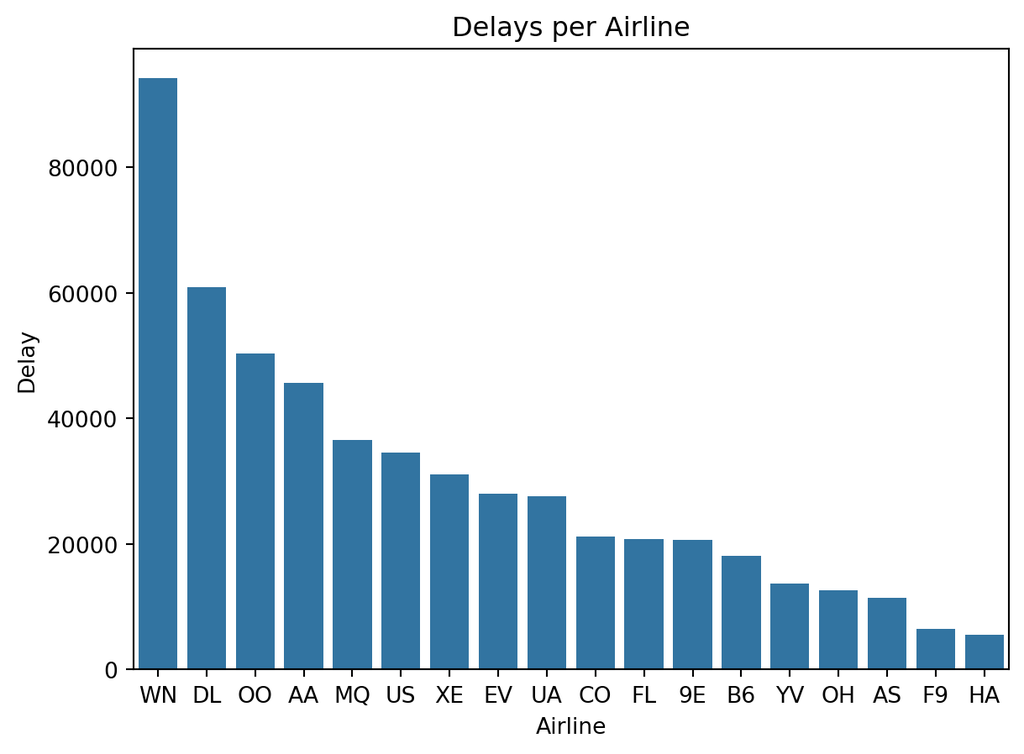

```python
airline_delays = group_and_sort_delays('Airline')
g = sns.barplot(airline_delays, x='Airline', y='Delay')
g.set(title = "Delays per Airline")
plt.show()
```

Origin

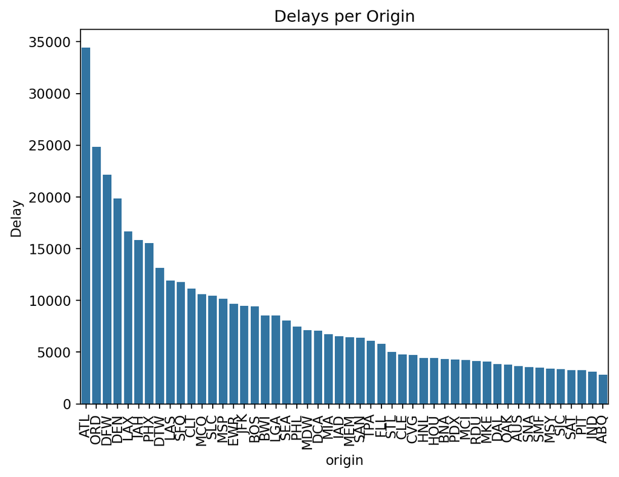

```python
# since there are so many unique origins, just use the top 50
origin_delays = group_and_sort_delays('origin')
g = sns.barplot(origin_delays[:50], x='origin', y='Delay')
g.set(title = "Delays per Origin")
plt.xticks(rotation=90)
plt.show()
```

Destination

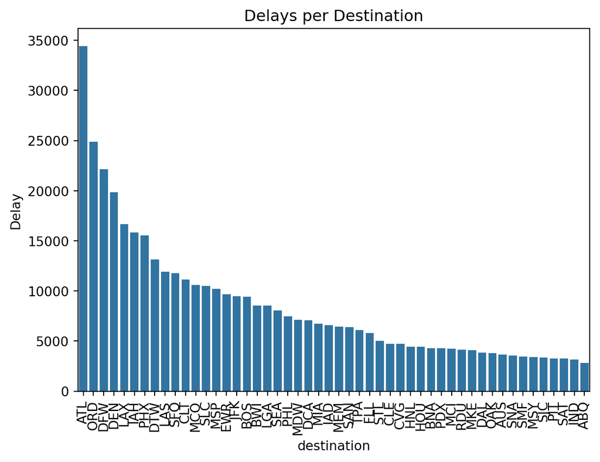

```python
# similar to above, just use top 50
dest_delays = group_and_sort_delays('destination')
g = sns.barplot(dest_delays[:50], x='destination', y='Delay')
g.set(title = "Delays per Destination")
plt.xticks(rotation=90)
plt.show()
```

```python
(origin_delays['origin'][:10]).equals(dest_delays['destination'][:10])
```

```
True
```

Day of week

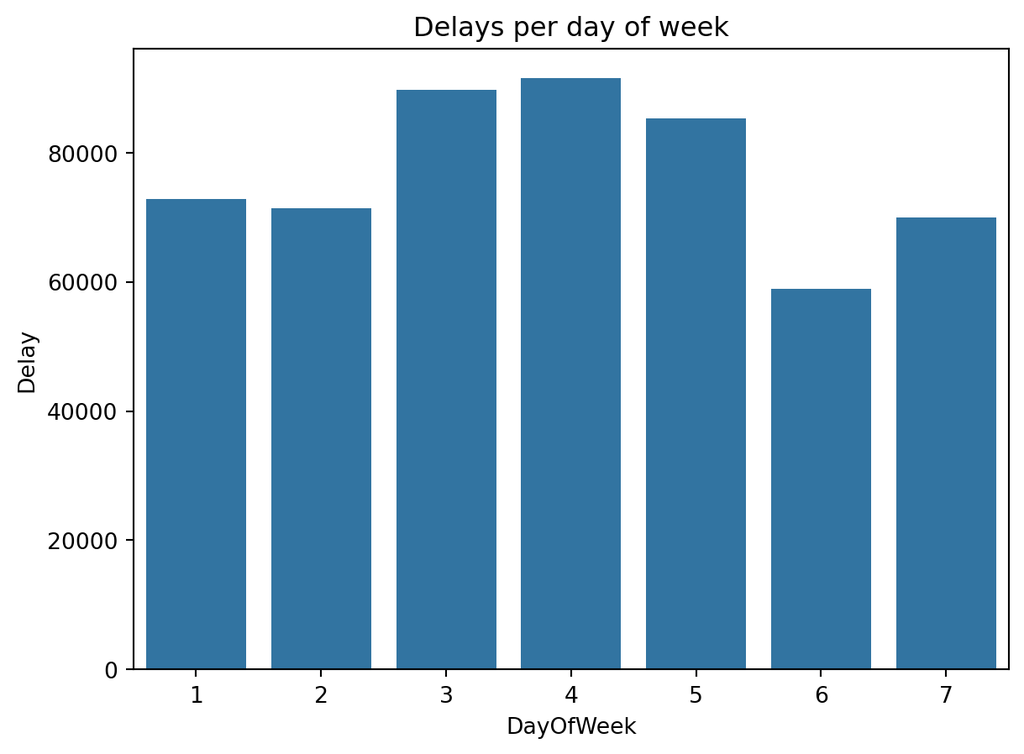

```python
day_delays = group_and_sort_delays('DayOfWeek')
g = sns.barplot(day_delays, x='DayOfWeek', y='Delay')
g.set(title = "Delays per day of week")
plt.show()
```

Duration

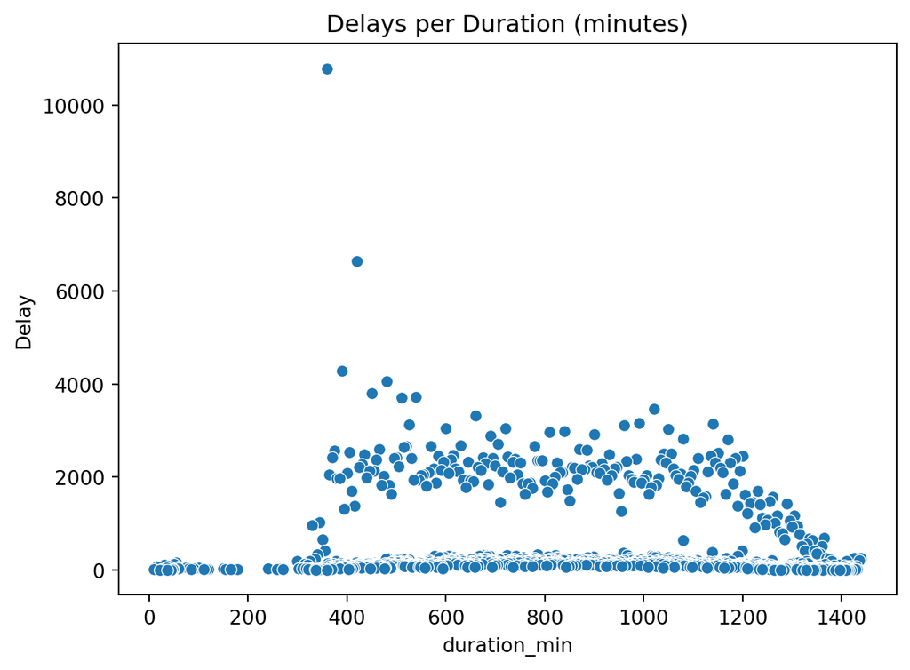

```python
duration_delays = group_and_sort_delays('duration_min')
g = sns.scatterplot(duration_delays, x='duration_min', y='Delay')
g.set(title = "Delays per Duration (minutes)")
plt.show()
```

Distance

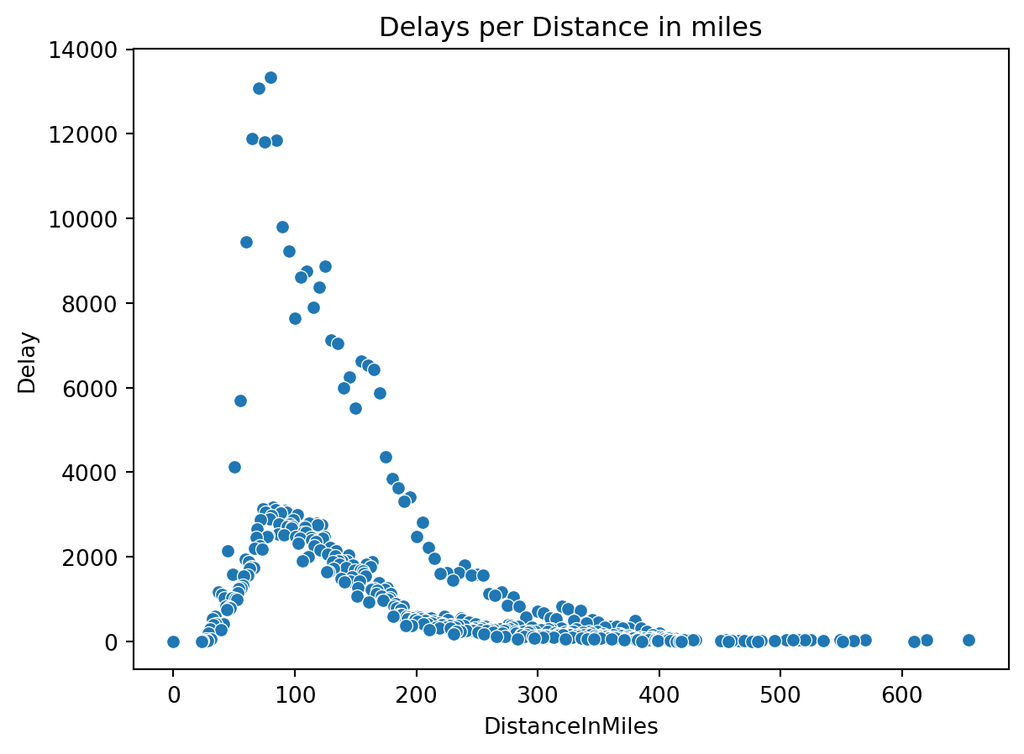

```python
distance_delays = group_and_sort_delays('DistanceInMiles')
g = sns.scatterplot(distance_delays, x='DistanceInMiles', y='Delay')
g.set(title = "Delays per Distance in miles")
plt.show()
```

Patterns seen:

```
* airline
    * Most delays in WN, DL, OO, AA, and MQ
* origin and destination
    * Routes with the most delays are the same for origin and destination
* day of week
    * Delays happen the most on Tuesday (3) and Wednesday (4)
* duration in minutes
    * No strong correlation
* distance
    * Spike in delays around 100 miles
```

**Specific Routes:**

How many unique routes (based on the original flight number variable) are in this dataset? Find the min, max, and median number of observations per route.

```python
print("unique routes:", df['FlightNumber'].nunique())

routes = df['FlightNumber'].value_counts()

print("min:", routes.min())
print("max:", routes.max())
print("median:", routes.median())
```

```
unique routes: 18170
min: 1
max: 175
median: 30.0
```

Are there any particular routes that are more likely to be delayed? Are these outliers consistent with the overall trends of the dataset that you observed in the previous question?

```python
route_delays = group_and_sort_delays('Itinerary')

print("Specific routes with the most delays:")
print(route_delays[:15])
```

```
Specific routes with the most delays:
     Itinerary  Delay
2204   LAX/SFO   1079
3744   SFO/LAX   1077
2913   OGG/HNL    982
1650   HNL/OGG    951
2199   LAX/SAN    935
3571   SAN/LAX    935
2099   LAS/LAX    928
2176   LAX/LAS    928
2238   LGA/ATL    916
168    ATL/LGA    915
2272   LGA/ORD    874
3052   ORD/LGA    842
127    ATL/DFW    818
1070   DFW/ATL    818
2174   LAX/JFK    812
```

### Part 2: Tourism Data

First you will need to tidy the data.

0. Remove the extra lines at the bottom of the file describing the data source
1. Remove the `Units` column since it provides no information
2. Pivot the data from wide to long, resulting in a `year` column and a `days` column
3. Separate out the statewide data into its own dataframe called `statewide` and remove the `Indicator` column from that dataframe since it provides no information
4. For the remaining data, rename the `Indicator` column to `island` and clean up the values to only include the name of the island (removing “LOS on”)
5. Make sure that all columns have been recast as the appropriate type!

```python
import numpy as np
import pandas as pd
import matplotlib as mpl
import matplotlib.pyplot as plt
import seaborn as sns

data_hawaii = pd.read_csv("./../../datasets/HawaiiTourismData.csv")
data_hawaii.head()

# 0. Remove the extra lines at the bottom of the file describing the data source
data_hawaii = data_hawaii.iloc[:116,:]

# 1. Remove the `Units` column since it provides no information
data_hawaii.drop(columns='Units', axis=1, inplace=True)

# 2. Pivot the data from wide to long, resulting in a `year` column and a `days` column
df_long = pd.melt(data_hawaii, id_vars=['Group', 'Indicator'], var_name='year', value_name='days')

df_long['year'] = df_long['year'].astype(int)

# 3. Separate out the statewide data into its own dataframe called `statewide` and remove the `Indicator` column from that dataframe since it provides no information
df_islands = df_long[df_long['Indicator'] != 'LOS Statewide']
df_statewide = df_long[df_long['Indicator'] == 'LOS Statewide']
df_statewide.drop(columns='Indicator', axis=1, inplace=True)

# 4. For the remaining data, rename the `Indicator` column to `island` and clean up the values to only include the name of the island (removing "LOS on ")
df_islands.rename(columns={'Indicator':'island'}, inplace=True)
df_islands['island'] = df_islands['island'].str[6:] # cut off first 7 characters

# 5. Make sure that all columns have been recast as the appropriate type!
print("\ndf_islands data types:")
print(df_islands.dtypes)

print("\ndf_statewide data types:")
print(df_statewide.dtypes)
```

```
df_islands data types:
Group      object
island     object
year        int64
days      float64
dtype: object

df_statewide data types:
Group     object
year       int64
days     float64
dtype: object
```

Next we will do some data analysis.

- Print out all the unique values for `Group`. Which groups would make sense to cluster together? (e.g. family-related or wedding-related). Use these clusters of groups to split the data into multiple plots for subsequent questions.

```python
print("unique group values:\n")
print(df_long['Group'].unique())
```

```
unique group values:

['All visitors by air' 'Hotel-only visitors' 'First-time visitors'
 'Honeymoon visitors' 'Condo-only visitors' 'Repeat visitors'
 'Get-married visitors' 'Timeshare-only visitors' 'MCI visitors'
 'Rental house visitors' 'Visiting Friends/Relatives' 'B&B visitors'
 'Family visitors']
```

Clusters I would make:

Wedding: - Honeymoon visitors - Get-married visitors

Lodging: (not sure what else to call this) - Condo-only visitors - Hotel-only visitors - Rental house visitors - B&B visitors - Timeshare-only visitors

Frequency: - First-time visitors - Repeat visitors

Relationship: - Visiting Friends/Relatives - Family visitors

Business: - MCI visitors (Assuming MCI stands for “Meetings, Convention & Incentives”)

All visitors by air would probably be its own cluster.

```python
# cluster dict
groups = {
    'All' : ['All visitors by air'],
    'Wedding' : ['Honeymoon visitors', 'Get-married visitors'],
    'Lodging' : ['Condo-only visitors', 'Hotel-only visitors',
                'Rental house visitors', 'B&B visitors',
                'Timeshare-only visitors'],
    'Frequency' : ['First-time visitors', 'Repeat visitors'],
    'Relationship' : ['Visiting Friends/Relatives', 'Family visitors'],
    'Business' : ['MCI visitors']
}

# clusters for statewide data
statewide_all = df_statewide[df_statewide['Group'].isin(groups['All'])]
statewide_wedding = df_statewide[df_statewide['Group'].isin(groups['Wedding'])]
statewide_lodging = df_statewide[df_statewide['Group'].isin(groups['Lodging'])]
statewide_freq = df_statewide[df_statewide['Group'].isin(groups['Frequency'])]
statewide_relation = df_statewide[df_statewide['Group'].isin(groups['Relationship'])]
statewide_business = df_statewide[df_statewide['Group'].isin(groups['Business'])]

# clusters for island data
islands_all = df_islands[df_islands['Group'].isin(groups['All'])]
islands_wedding = df_islands[df_islands['Group'].isin(groups['Wedding'])]
islands_lodging = df_islands[df_islands['Group'].isin(groups['Lodging'])]
islands_freq = df_islands[df_islands['Group'].isin(groups['Frequency'])]
islands_relation = df_islands[df_islands['Group'].isin(groups['Relationship'])]
islands_business = df_islands[df_islands['Group'].isin(groups['Business'])]
```

- Use the **statewide data** to plot the average length of stay over time by group, creating one plot for each group cluster you created in the previous question.

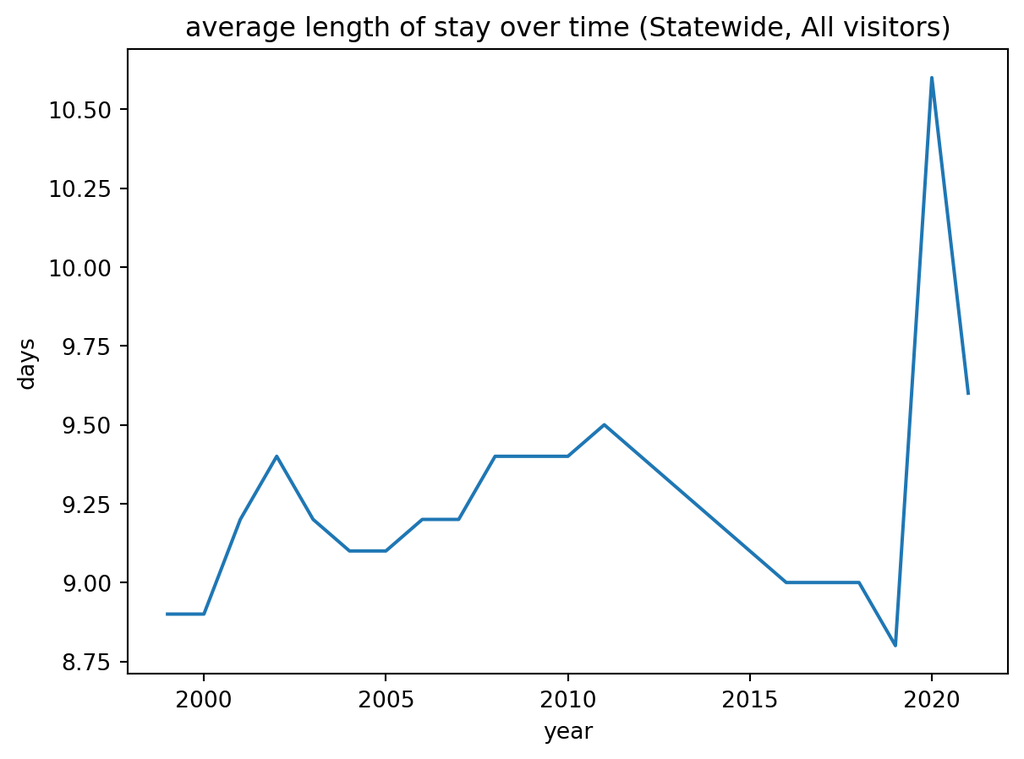

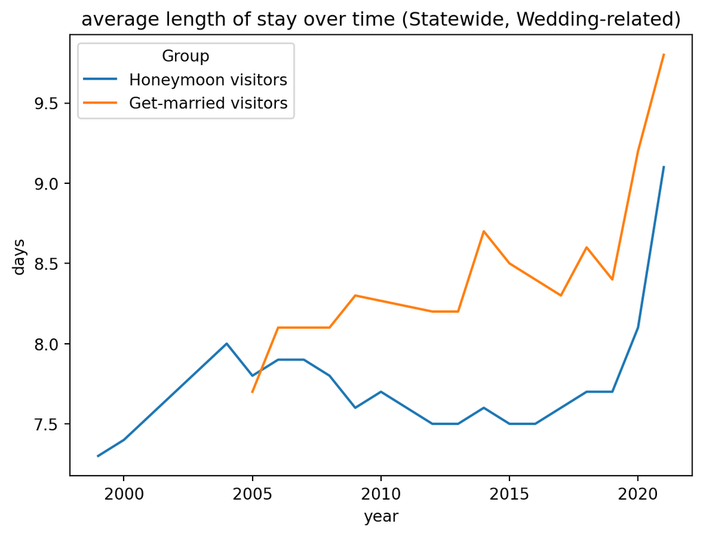

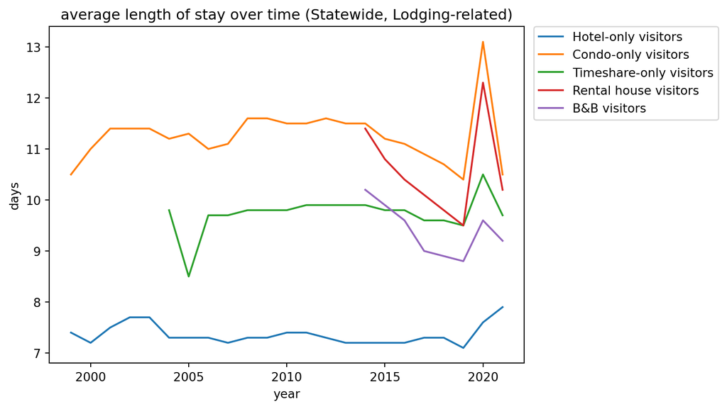

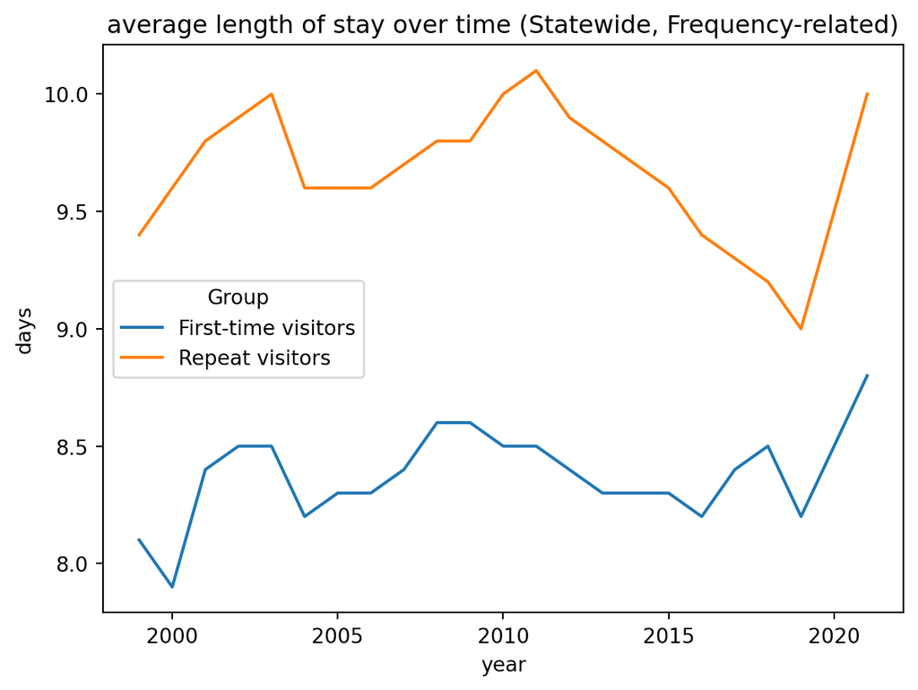

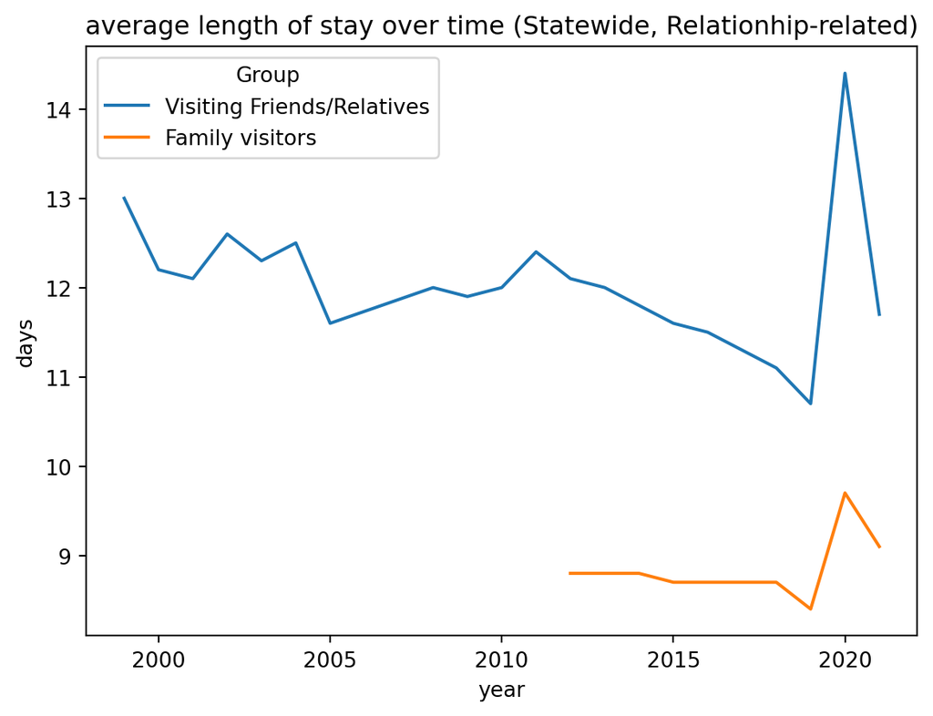

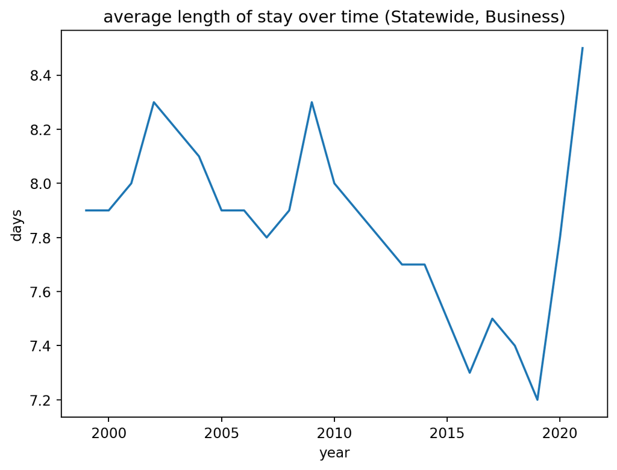

```python
# All visitors
g = sns.lineplot(statewide_all, x='year', y='days')
g.set(title = 'average length of stay over time (Statewide, All visitors)')
plt.show()

# Wedding
g = sns.lineplot(statewide_wedding, x='year', y='days', hue='Group')
g.set(title = 'average length of stay over time (Statewide, Wedding-related)')
plt.show()

# Lodging
g = sns.lineplot(statewide_lodging, x='year', y='days', hue='Group')
g.set(title = 'average length of stay over time (Statewide, Lodging-related)')
plt.legend(bbox_to_anchor=(1.02, 1), loc='upper left', borderaxespad=0)
plt.show()

# Frequency
g = sns.lineplot(statewide_freq, x='year', y='days', hue='Group')
g.set(title = 'average length of stay over time (Statewide, Frequency-related)')
plt.show()

# Relationship
g = sns.lineplot(statewide_relation, x='year', y='days', hue='Group')
g.set(title = 'average length of stay over time (Statewide, Relationhip-related)')
plt.show()

# Business
g = sns.lineplot(statewide_business, x='year', y='days')
g.set(title = 'average length of stay over time (Statewide, Business)')
plt.show()
```

- Use the **island data** to plot the average length of stay for visitors by air for each island over time in a single plot.

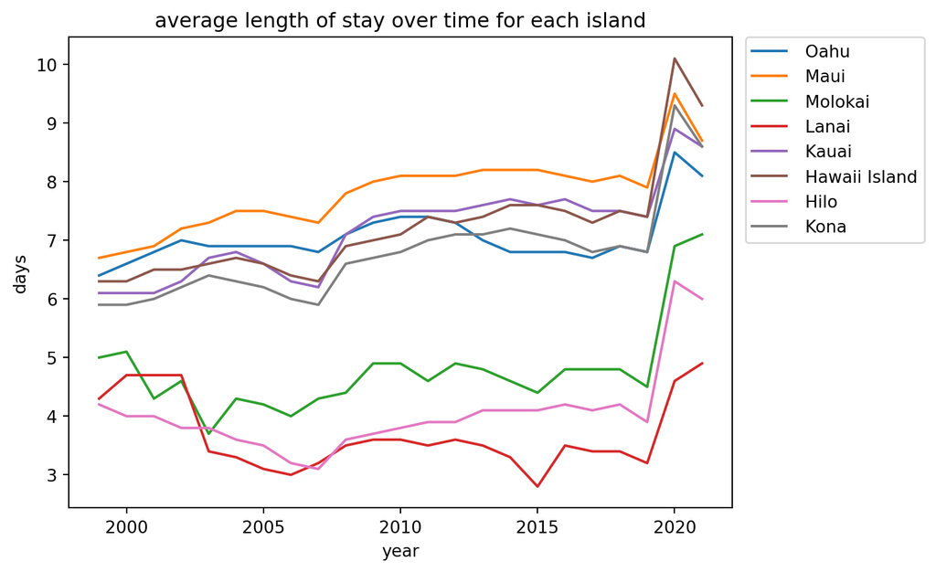

```python
g = sns.lineplot(df_islands[df_islands['Group'] == 'All visitors by air'], x='year', y='days', hue='island')

g.set(title = 'average length of stay over time for each island')
plt.legend(bbox_to_anchor=(1.02, 1), loc='upper left', borderaxespad=0)
plt.show()
```

- Using the island data from 2021 only, create one plot for each group cluster showing the average length of stay by group for each island.

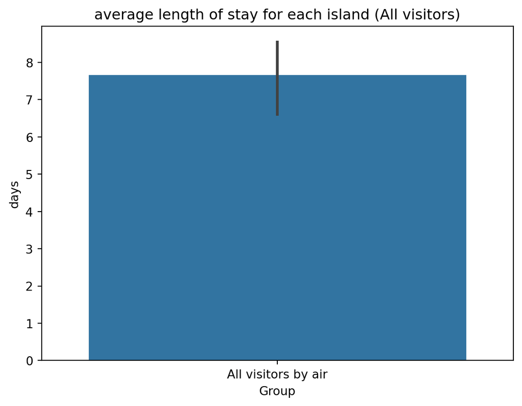

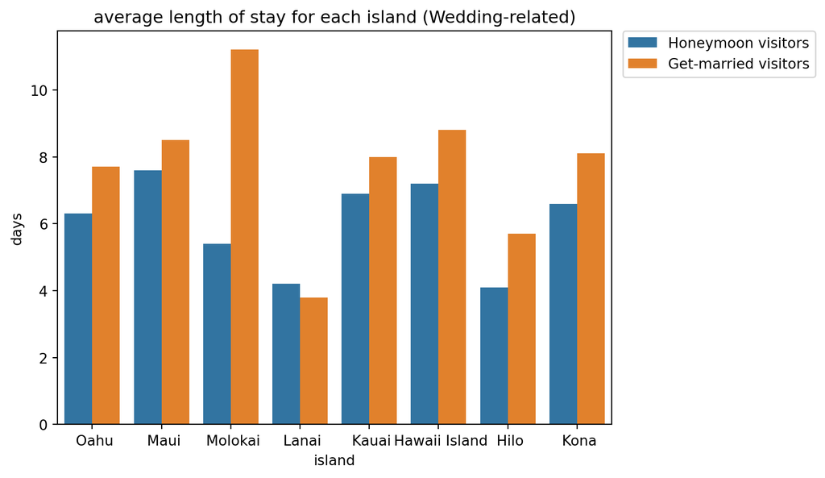

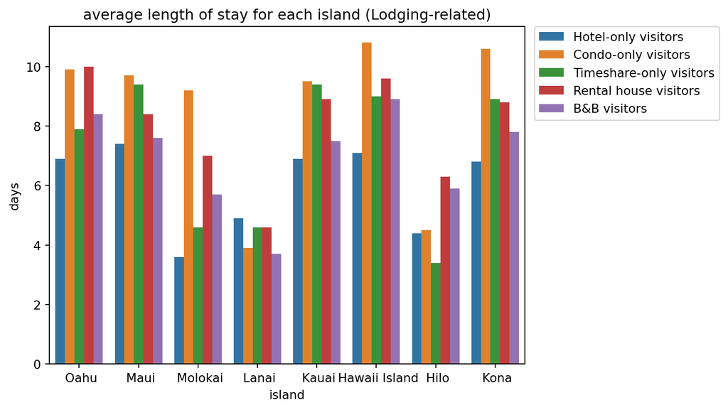

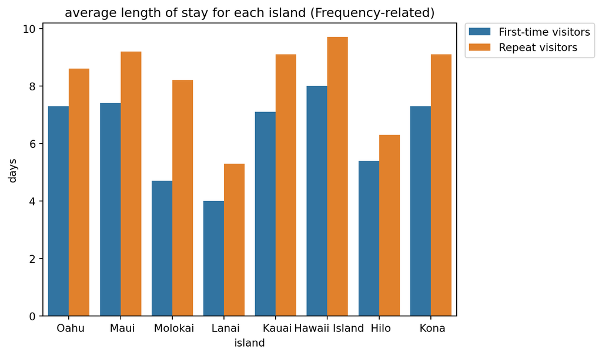

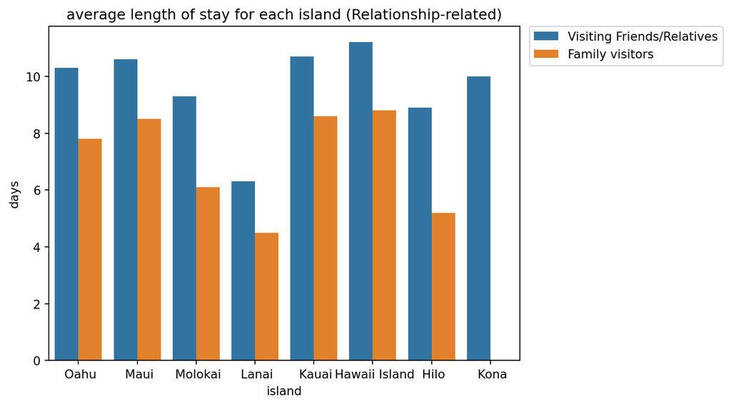

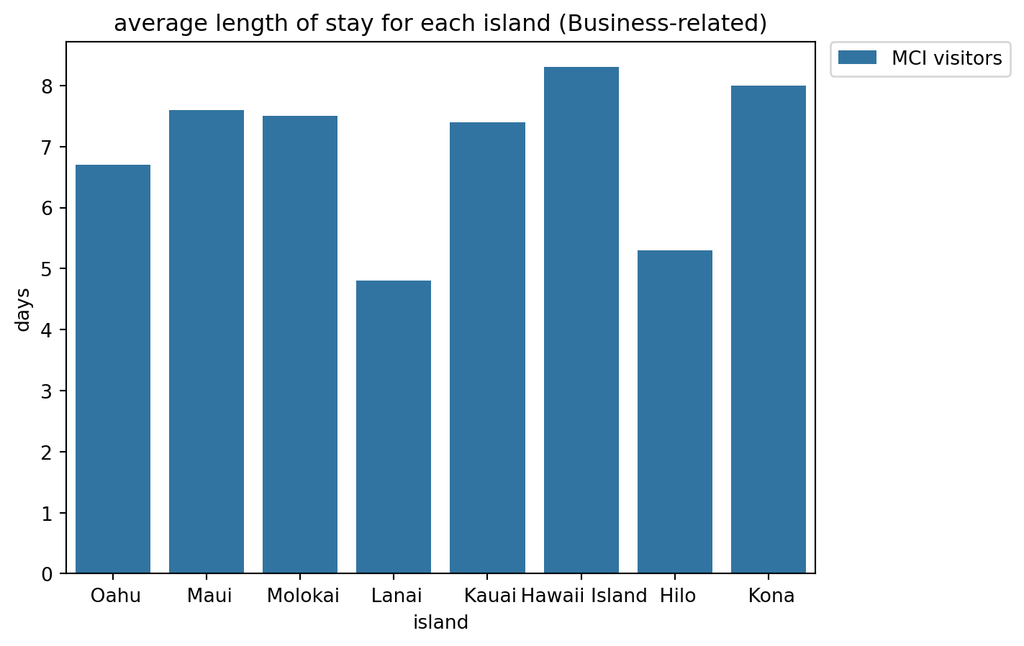

```python
def only_2021(df):
    return df[df['year'] == 2021]

# All visitors
g = sns.barplot(only_2021(islands_all), x='Group', y='days')
g.set(title = 'average length of stay for each island (All visitors)')
plt.show()

# Wedding
g = sns.barplot(only_2021(islands_wedding), x='island', y='days', hue='Group')
g.set(title = 'average length of stay for each island (Wedding-related)')
plt.legend(bbox_to_anchor=(1.02, 1), loc='upper left', borderaxespad=0)
plt.show()

# Lodging
g = sns.barplot(only_2021(islands_lodging), x='island', y='days', hue='Group')
g.set(title = 'average length of stay for each island (Lodging-related)')
plt.legend(bbox_to_anchor=(1.02, 1), loc='upper left', borderaxespad=0)
plt.show()

# Frequency
g = sns.barplot(only_2021(islands_freq), x='island', y='days', hue='Group')
g.set(title = 'average length of stay for each island (Frequency-related)')
plt.legend(bbox_to_anchor=(1.02, 1), loc='upper left', borderaxespad=0)
plt.show()

# Relationship
g = sns.barplot(only_2021(islands_relation), x='island', y='days', hue='Group')
g.set(title = 'average length of stay for each island (Relationship-related)')
plt.legend(bbox_to_anchor=(1.02, 1), loc='upper left', borderaxespad=0)
plt.show()

# Business
g = sns.barplot(only_2021(islands_business), x='island', y='days', hue='Group')
g.set(title = 'average length of stay for each island (Business-related)')
plt.legend(bbox_to_anchor=(1.02, 1), loc='upper left', borderaxespad=0)
plt.show()
```

### Extra Credit

For the extra credit, you will combine both datasets! The commercial airports in Hawaii for which we have flight data have the following abbreviations:

- ITO - Hilo
- HNL - Oahu
- OGG - Maui
- KOA - Hawaii
- LIH - Kauai
- MKK - Molokai
- LNY - Lanai

For the flight data, create a new dataframe containing only the flights that include these airports in either the origin or destination. Then create a summary dataframe that has the following columns:

- Airport abbreviation
- Number of origin flights
- Number of destination flights
- Percentage of delays for origin flights
- Percentage of delays for destination flights

For the tourism data, create a new dataframe containing only the “All visitors by air” data for each island for the year 2021. Add a column to this dataframe with the airport code for each island.

Now perform an **left join** on airport code between the two dataframes, with the tourism data on the left. Your final dataframe should have one row for each island, with the following columns:

- Number of origin flights
- Number of destination flights
- Origin delay percentage
- Destination delay percentage
- 2021 visitors by air

Write some comments on your observations for these data.